# Analysis of periodontal bacteria in relation to disease status and pocket depth

The following notebook performs multidimensional scaling with the bacterial relative abundance data from PerioData.csv The notebook follows the code from: https://environmentalcomputing.net/graphics/multivariate-vis/mds/

```r
library(vegan)
library(ggplot2)
```

### Read Data

Make data frame from the periodontal data file PerioData.csv

```r
perio <- read.csv("PerioData.csv")
head(perio)
```

|  | id | strep | prev | lepto | fuso | veil | time | status | pocket | deepest | range |
| --- | --- | --- | --- | --- | --- | --- | --- | --- | --- | --- | --- |
| 1 | S001 | 57.4 | 10.2 | 0.1 | 0.0 | 6.9 | 1 | 2 | 2.7 | 3.8 | middle |
| 2 | S001 | 26.0 | 0.0 | 25.6 | 0.0 | 6.3 | 2 | 2 | 2.7 | 3.0 | middle |
| 3 | S006 | 19.0 | 24.2 | 4.8 | 5.7 | 4.2 | 1 | 1 | 2.5 | 3.2 | middle |
| 4 | S006 | 15.2 | 4.2 | 0.2 | 2.6 | 3.4 | 2 | 1 | 2.4 | 3.2 | middle |
| 5 | S007 | 33.2 | 2.3 | 7.4 | 1.3 | 12.0 | 1 | 2 | 2.4 | 2.7 | shallow |
| 6 | S007 | 18.0 | 0.3 | 13.6 | 1.7 | 13.8 | 2 | 2 | 2.4 | 2.8 | shallow |

Subset the perio data to only have bacterial columns. The next block performs non-metric multidimentional scaling (NMDS) using bray-curtis distances of the bacterial relative abundances. The plot shows all the samples ordinated on this first two axes, MDS1 and MDS2.

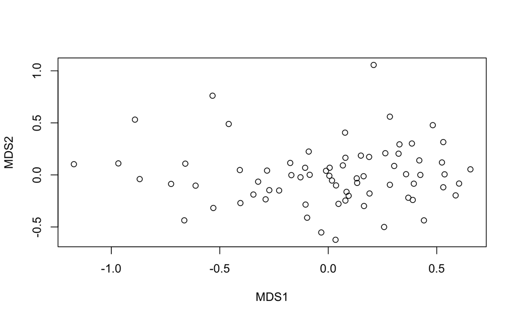

```r
bacteria <- perio[2:6]
#head(bacteria)
bacteria.mds <- metaMDS(comm = bacteria, distance = "bray", trace = FALSE, autotransform = FALSE)
plot(bacteria.mds$points)
```

This block assigns the metadata to the sampes in the plot, then the ggplot colors the points in the graph for one variable, in this case disease status.

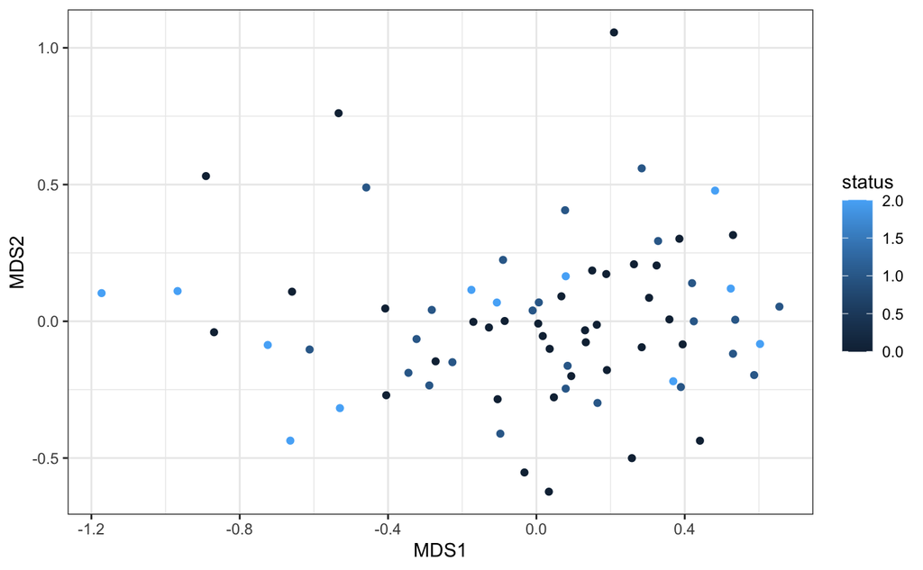

```r
bacteria_xy <- data.frame(bacteria.mds$points)
bacteria_xy$status <- perio$status #disease status 1=not disease; 2=diseased
bacteria_xy$time <- perio$time     #time point
bacteria_xy$range <- perio$range   #range of pocket depth shallow < 3mm, middle 3-3.9, deep 4+

ggplot(bacteria_xy, aes(MDS1, MDS2, color = status)) +
  geom_point() +
  theme_bw()
```

Finally, this block performs a PERMANOVA statistical analysis. This is an ANOVA using distance matrices that uses permutations to ask if the samples group clusters are the same or not. In effect, for this next test, we are asking if there is a difference between the beta diversity of the samples based on disease status.

Here is the full formula for the adnonis2 function that runs the PERMANOVA. By default it performs 999 permutation and uses bray curtis distances. adonis2(formula, data, permutations = 999, method = “bray”, sqrt.dist = FALSE, add = FALSE, by = NULL, parallel = getOption(“mc.cores”), na.action = na.fail, strata = NULL, …)

```r
adonis2(bacteria ~ perio$status) # is there a significant different in the samples base on status?
```

```
Permutation test for adonis under reduced model
Permutation: free
Number of permutations: 999

adonis2(formula = bacteria ~ perio$status)
         Df SumOfSqs      R2     F Pr(>F)
Model     1   0.1077 0.01633 1.162   0.31
Residual 70   6.4890 0.98367
Total    71   6.5968 1.00000
```

No, there is not a significant difference between the samples based on the disease status (p = 0.31).

```r
adonis2(bacteria ~ perio$time + perio$range)
```

```
Permutation test for adonis under reduced model
Permutation: free
Number of permutations: 999

adonis2(formula = bacteria ~ perio$time + perio$range)
         Df SumOfSqs      R2      F Pr(>F)
Model     3   0.7688 0.11654 2.9899  0.003 **
Residual 68   5.8280 0.88346
Total    71   6.5968 1.00000
---
Signif. codes:  0 ‘***’ 0.001 ‘**’ 0.01 ‘*’ 0.05 ‘.’ 0.1 ‘ ’ 1
```

EXERCISE 2: REPEAT the analyses above after rclr transformation of the bacteria data.